# Swiftkey Corpus - Initial Analysis

BWH

10/28/2017

```r
library(ggplot2)
library(quanteda)
```

# Getting the Data

My first step is to acquire the data, with the assumption that I’ve downloaded the dataset from the Coursera website. I’ll then proceed to clean it and work through the steps of getting a sense of the problem at hand.

```r
unzip('Coursera-Swiftkey.zip')
```

This call created an extracted folder called `final` that has the text files. I will be focusing on the English corpora.

# Exploratory analysis and cleaning.

My first task is to get a sense of the file size, both in terms of number of lines to be analyzed and overall size of the files as these will affect my analytic approach and sample size.

```bash
CORPORA="final/en_us/*"
# Get the size of the files
ls -alh final/en_us

for file in $CORPORA
do
  wc -l $file
done

for file in $CORPORA
do
  wc -w $file
done
```

```
## total 1138840
## drwxr-xr-x  5 bhicks  staff   160B Oct 28 17:32 .
## drwxr-xr-x  6 bhicks  staff   192B Oct 28 17:32 ..
## -rw-r--r--  1 bhicks  staff   200M Oct 29 16:47 en_US.blogs.txt
## -rw-r--r--  1 bhicks  staff   196M Oct 29 16:47 en_US.news.txt
## -rw-r--r--  1 bhicks  staff   159M Oct 29 16:47 en_US.twitter.txt
##   899288 final/en_us/en_US.blogs.txt
##  1010242 final/en_us/en_US.news.txt
##  2360148 final/en_us/en_US.twitter.txt
##  37334690 final/en_us/en_US.blogs.txt
##  34372720 final/en_us/en_US.news.txt
##  30374206 final/en_us/en_US.twitter.txt
```

From this quick glance using Bash, we can see that the files are around 150 - 200 MB, with the most lines in the `en_US.twitter.txt`. Line numbers are roughly 900,000, 1 million, and 2 million respectively. These are larger files, so training models on a subset will be a useful mechanism. Note also the word counts.

To clean these files, I will be using `quanteda`, a package that combines text mining functionality with advanced tokenization.

The initial cleanup is primarily oriented around removing numbers, punctuation, whitespace, lowering all charcters, and pulling out English stop words. I am not yet removing profanity or stemming the words (i.e. reducing them to their lemma). The latter is for usability purposes in my work, and the former because I suspect leaving profanity in while building a model may be useful.

I am also subsetting each corpus to around 10,000 lines while developing my analysis.

```r
blogs <- file('final/en_US/en_US.blogs.txt')
news <- file('final/en_US/en_US.news.txt')
twitter <- file('final/en_US/en_US.news.txt')

blog_snip <- readLines(blogs, 10000)
news_snip <- readLines(news, 10000)
twitter_snip <- readLines(twitter, 10000)

close(blogs)
close(news)
close(twitter)
```

```r
sample <- c(blog_snip, news_snip, twitter_snip)

full_clear <- function(ngrams = 1) {
  dfm(sample, ngrams = ngrams, remove = stopwords('english'),
      remove_punct = TRUE, remove_numbers = TRUE,
      remove_symbols=TRUE)
}

unigrams <- full_clear()
bigrams <- full_clear(2)
trigrams <- full_clear(3)
```

We now have a set of 30,000 lines that are cleaned for purposes of n-gram tokenization, which will give us some clue about unique words. `dfm` implictly lower cases the results. Note that for this analysis, stop words are removed after creating ngrams, so ‘the’ will be filtered but ‘that of the’ would not be. See below for discussion.

# N-Gram Tokenization

N-grams are a series of contiguous items in a string of speech, in this case, most likely words. I will analyze Unigrams, Bigrams, and Trigrams to look for relative frequencies for the top 15-20 each.

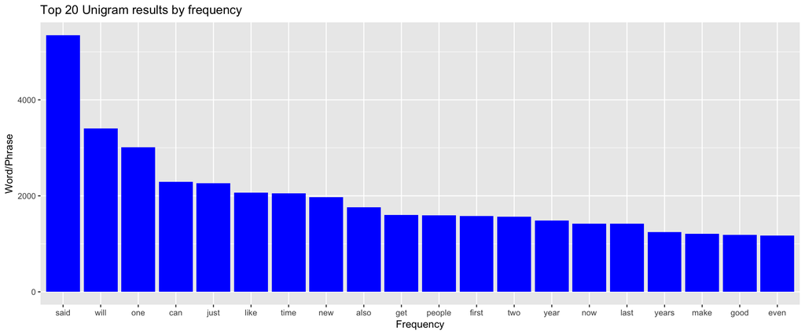

```r
unifreq <- topfeatures(unigrams, 20)
unidf <- data.frame(unigrams = names(unifreq), frequency = unifreq)
ggplot(unidf, aes(x=reorder(unigrams, -unifreq), y = frequency)) +
  geom_bar(stat = "identity", fill = "blue") +
  ggtitle('Top 20 Unigram results by frequency') +
  ylab('Word/Phrase') +
  xlab('Frequency')
```

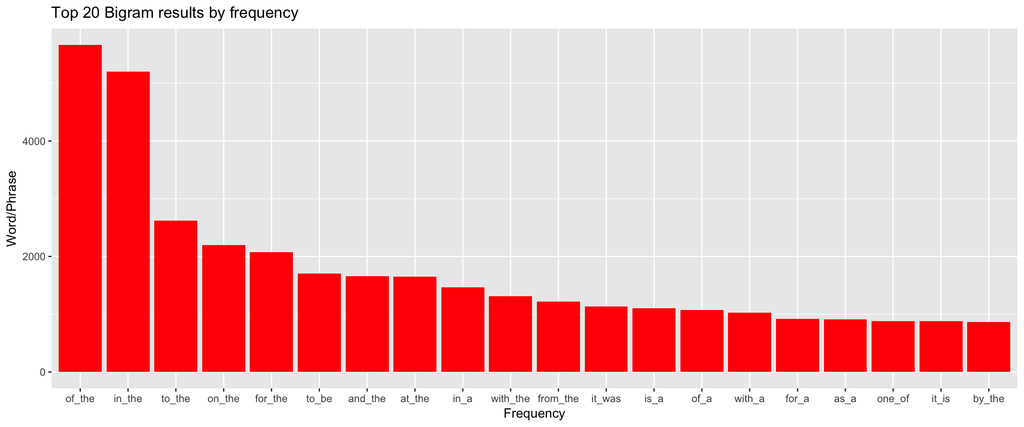

```r
bifreq <- topfeatures(bigrams, 20)
bidf <- data.frame(bigrams = names(bifreq), frequency = bifreq)
ggplot(bidf, aes(x=reorder(bigrams, -bifreq), y = frequency)) +
  geom_bar(stat = "identity", fill = "red") +
  ggtitle('Top 20 Bigram results by frequency') +
  ylab('Word/Phrase') +
  xlab('Frequency')
```

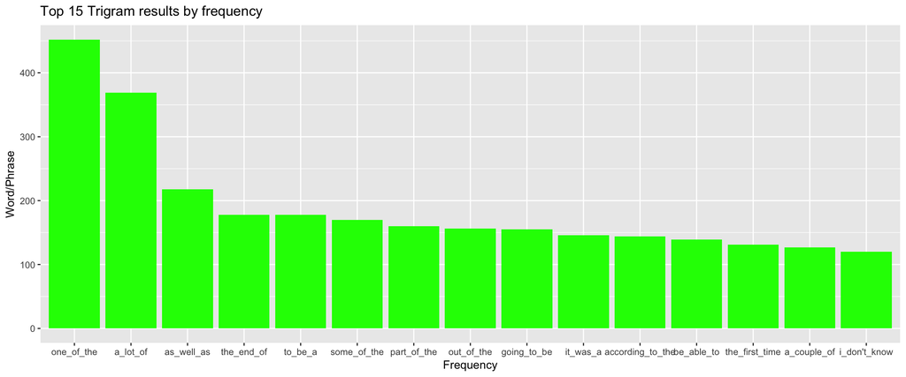

```r
trifreq <- topfeatures(trigrams, 15)
tridf <- data.frame(trigrams = names(trifreq), frequency = trifreq)
ggplot(tridf, aes(x=reorder(trigrams, -trifreq), y = frequency)) +
  geom_bar(stat = "identity", fill = "green") +
  ggtitle('Top 15 Trigram results by frequency') +
  ylab('Word/Phrase') +
  xlab('Frequency')
```

It is worth noting a comparison on the trigram prefiltering all stop words before constructing a data frequency matrix and ngrams.

```r
tokenized <- tokens(sample, remove_punct = TRUE,
                       remove_numbers = TRUE, remove_symbols=TRUE)
noStops <- removeFeatures(tokenized, stopwords("english"))
trigramNoStops <- tokens_ngrams(noStops, 3)
topfeatures(dfm(trigramNoStops), 15)
```

```
##          new_york_city          two_years_ago       first_time_since
##                     30                     28                     28
##         new_york_times president_barack_obama     gov_chris_christie
##                     27                     26                     22
##   pates_fountain_parks           world_war_ii     u.s_district_court
##                     22                     19                     18
##        st_louis_county          two_weeks_ago   high_school_students
##                     18                     16                     16
## classic_pates_fountain        osama_bin_laden            12u_14u_16u
##                     16                     14                     14
```

# Predictive Algorithm and Plans for Shiny App

This exploratory analysis suggests a few ways forward for the Shiny App. A frequency table lookup against two sets of possibilities, offering a top ~three choices makes the most sense.

This will accomodate both approaches that remove stop words for unigrams, but allow them for bi and trigrams as they often suggest intelligent phrases, and other approaches that emphasize finding distinct words and phrases (i.e. in the last table, ‘new york’ should almost certainly offer ‘city’ as a prediction)

The basic structure of the Shiny App would receive words or words, and then lookup based on frequency models built from the training corporta to guess at both words following from stopwords and words following from stop words removed.